# Séries temporelles : Correction TP 3

A. Hardy

16 février 2017

Dans ce TP, on utilise les librairies :

```r
library(caschrono)
library(forecast)
library(astsa)
```

# EXERCICE 1

## Question 1

L’équation est celle d’un processus AR(2)

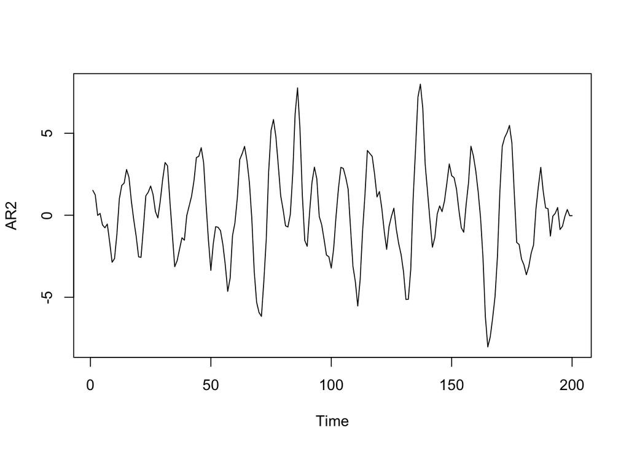

```r
AR2 <- arima.sim(list(ar=c(1.5,-0.75)), n=200); plot(AR2)
```

Ce processus est stationnaire car les racines $r_1$ et $\bar{r_1}$ du polynome associé $P(z)=0.75z^2-1.5z+1$ sont de module différent de 1 :

```r
D <- 1.5^2-4*0.75; r1 <- (1.5+sqrt(-D)*1i)/(2*0.75) ; abs(r1)
```

```
## [1] 1.154701
```

## Question 2

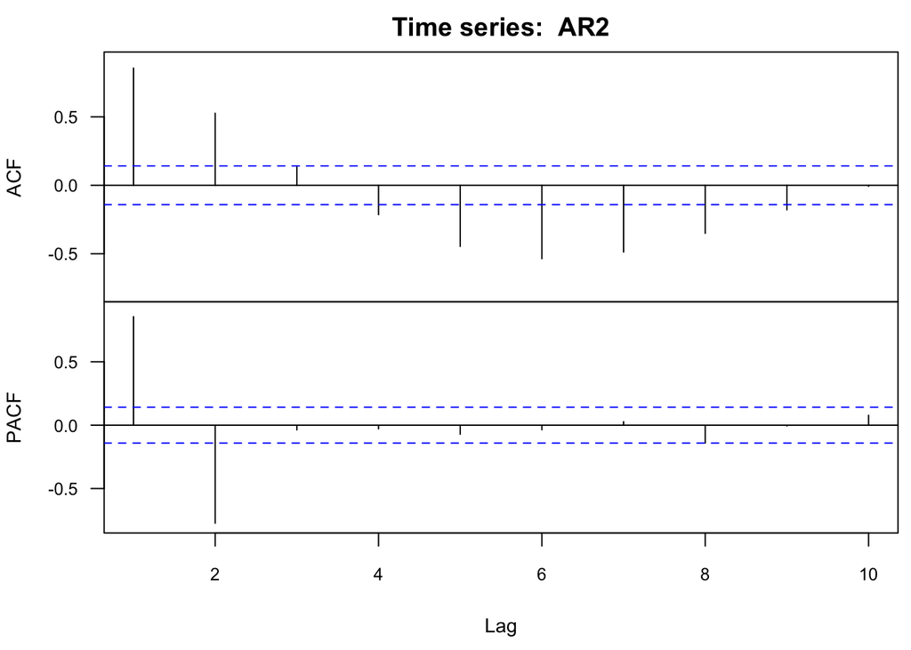

```
##       LAG        ACF1         PACF
##  [1,]   1  0.85603546  0.856035455
##  [2,]   2  0.52616947 -0.773295960
##  [3,]   3  0.13277324 -0.037102045
##  [4,]   4 -0.21438653 -0.029052612
##  [5,]   5 -0.44631054 -0.071530177
##  [6,]   6 -0.53575016 -0.036093056
##  [7,]   7 -0.48730469  0.027126412
##  [8,]   8 -0.35079430 -0.140712374
##  [9,]   9 -0.17891370 -0.006098879
## [10,]  10 -0.00757228  0.078017548
```

```r
#acf(AR2,10)
#pacf(AR2,10)
acf2y(AR2,10)
```

L’ACF ne semble pas être celle d’un MA, et la PACF ayant deux “piques” correspond à celle d’un AR(2).

## Question 3

On teste un AR(4) :

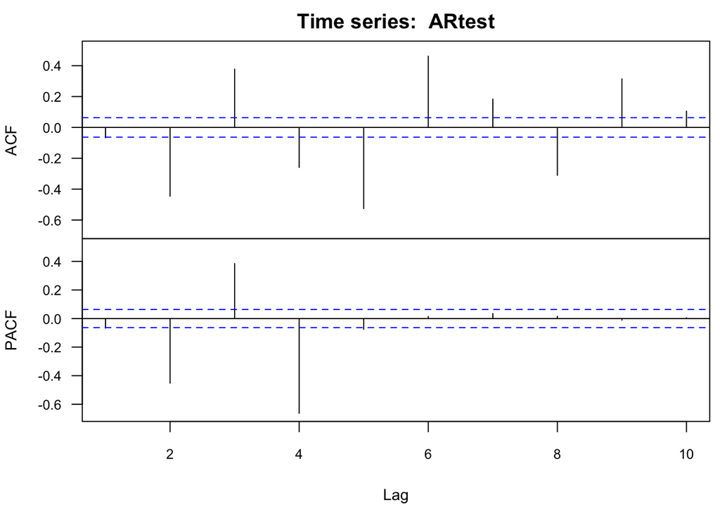

```
##       LAG        ACF1         PACF
##  [1,]   1 -0.06667859 -0.066678594
##  [2,]   2 -0.44566190 -0.452118064
##  [3,]   3  0.37820741  0.384961468
##  [4,]   4 -0.25902387 -0.663197174
##  [5,]   5 -0.52566172 -0.075178763
##  [6,]   6  0.46187512  0.014527176
##  [7,]   7  0.18316606  0.034646558
##  [8,]   8 -0.31032817  0.015894247
##  [9,]   9  0.31466680 -0.011568385
## [10,]  10  0.10546629  0.005375511
```

```r
ARtest <- arima.sim(list(ar=c(0.4,-0.75,0.5,-0.7)),n=1000)
acf2y(ARtest,10)
```

L’ACF nous montre clairement que ce n’est pas un MA, et la PACF indique un AR(4), car 4 piques en dehors de l’intervalle de confiance puis plus rien.

## Question 4

On commence toujours par une rapide étude graphique :

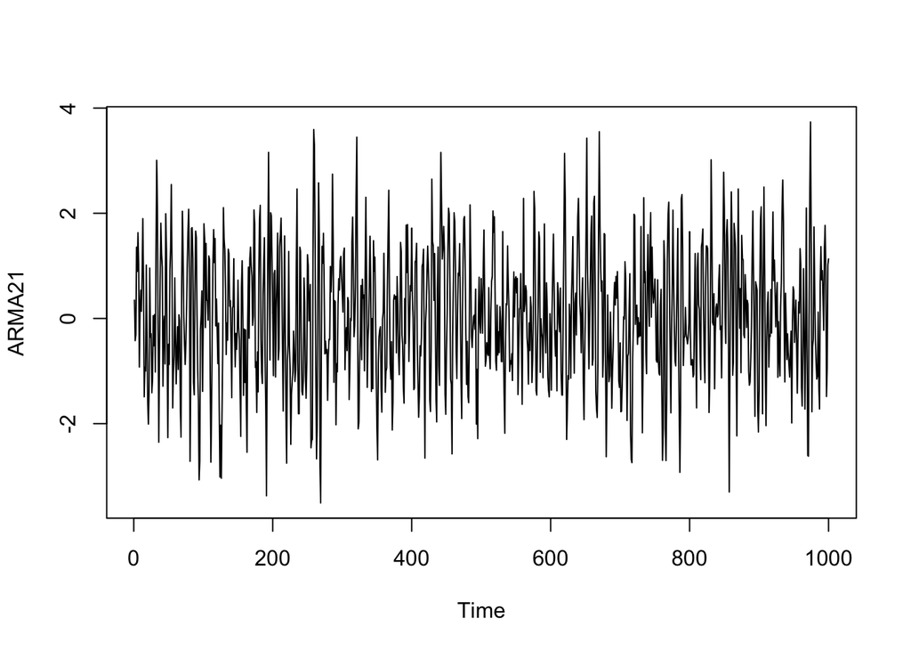

```r
ARMA21 <- arima.sim(list(ar = c(0.89, -0.5), ma = -0.23), n=1000) ; plot(ARMA21)
```

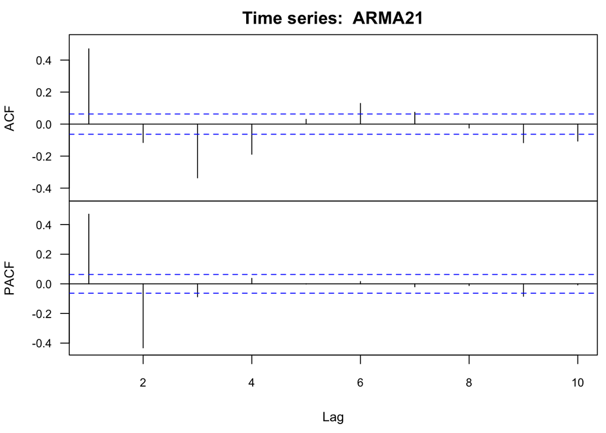

```
##       LAG        ACF1          PACF
##  [1,]   1  0.47055203  0.4705520343
##  [2,]   2 -0.11506388 -0.4321749355
##  [3,]   3 -0.33611263 -0.0871954998
##  [4,]   4 -0.18849998  0.0372538536
##  [5,]   5  0.02998299 -0.0009542228
##  [6,]   6  0.12932678  0.0155905941
##  [7,]   7  0.07389693 -0.0201419284
##  [8,]   8 -0.02455407 -0.0120333818
##  [9,]   9 -0.11643660 -0.0839408176
## [10,]  10 -0.10619936 -0.0076294751
```

```r
acf2y(ARMA21,10)
```

On estime l’ordre avec auto.arima et puis on étudie résidus :

```r
auto.arima(ARMA21)
```

```
## Series: ARMA21
## ARIMA(2,0,2) with zero mean
##
## Coefficients:
##          ar1      ar2      ma1     ma2
##       0.7481  -0.5290  -0.1084  0.0992
## s.e.  0.0721   0.0405   0.0797  0.0601
##
## sigma^2 estimated as 0.9793:  log likelihood=-1406.81
## AIC=2823.62   AICc=2823.68   BIC=2848.16
```

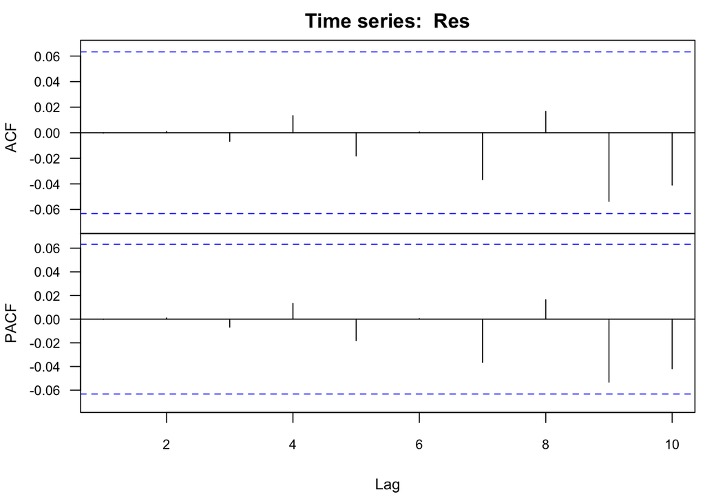

```
##       LAG          ACF1          PACF
##  [1,]   1 -0.0002302169 -0.0002302169
##  [2,]   2  0.0010053775  0.0010053245
##  [3,]   3 -0.0067278785 -0.0067274230
##  [4,]   4  0.0133738555  0.0133704151
##  [5,]   5 -0.0181590727 -0.0181448727
##  [6,]   6  0.0006331820  0.0005611278
##  [7,]   7 -0.0367027314 -0.0365094739
##  [8,]   8  0.0167681818  0.0163849149
##  [9,]   9 -0.0536310642 -0.0532279039
## [10,]  10 -0.0409455187 -0.0418541688
```

```r
Res <- auto.arima(ARMA21)$residuals
acf2y(Res,10)
```

```r
Box.test(Res)
```

```
##
##  Box-Pierce test
##
## data:  Res
## X-squared = 5.3e-05, df = 1, p-value = 0.9942
```

Conclusion : Le test de Box-Pierce ne permet pas de rejeter l’hypothèse d’un bruit blanc. La modélisation est donc pertinente.

# Exercice 2

```r
help(oil)
```

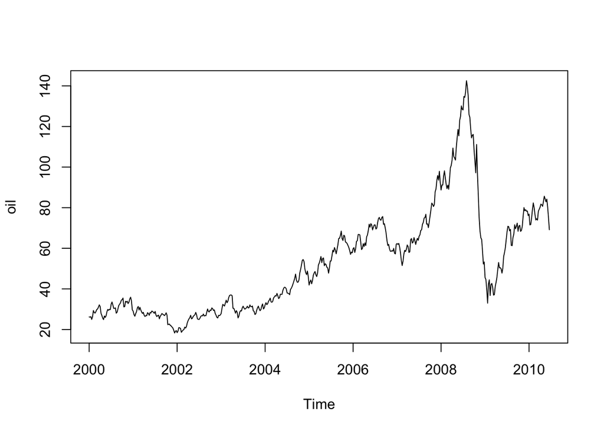

```r
plot(oil)
```

Ce chronogramme semble avoir une tendance : ça ne ressemble pas à une réalisation d’un processus stationnaire.

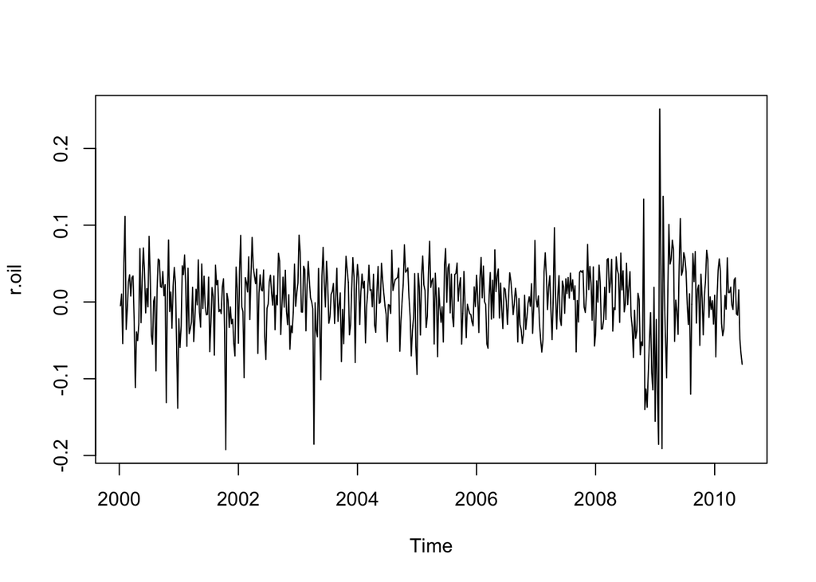

```r
# Calcul des log-rendements
r.oil <- diff(log(oil))
plot(r.oil)
```

Ce chronogramme ressemble plus à la réalisation d’un processus stationnaire que le précédent. La tendance a été lisée.

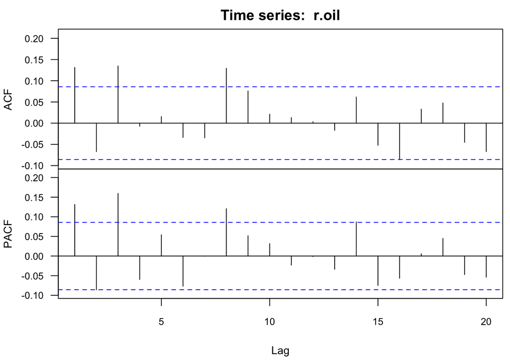

```
##       LAG         ACF1          PACF
##  [1,]   1  0.131303331  0.1313033315
##  [2,]   2 -0.067151512 -0.0858725683
##  [3,]   3  0.134740462  0.1594958503
##  [4,]   4 -0.007416312 -0.0596497008
##  [5,]   5  0.015468808  0.0542317276
##  [6,]   6 -0.033768496 -0.0768873667
##  [7,]   7 -0.034713442 -0.0003380219
##  [8,]   8  0.129331408  0.1206751658
##  [9,]   9  0.075972545  0.0517216606
## [10,]  10  0.021104848  0.0317191090
## [11,]  11  0.013195204 -0.0231050503
## [12,]  12  0.003433059 -0.0014644320
## [13,]  13 -0.016836043 -0.0336696012
## [14,]  14  0.061709186  0.0871322846
## [15,]  15 -0.052122650 -0.0749460361
## [16,]  16 -0.085654021 -0.0566749318
## [17,]  17  0.032952206  0.0060030598
## [18,]  18  0.047620321  0.0448886395
## [19,]  19 -0.045310214 -0.0472274611
## [20,]  20 -0.067042969 -0.0538996946
```

```r
acf2y(r.oil,20)
```

```r
# Modélisation avec un ARMA
auto.arima(r.oil, stationary=TRUE, seasonal=FALSE)
```

```
## Series: r.oil
## ARIMA(1,0,1) with zero mean
##
## Coefficients:
##           ar1     ma1
##       -0.5253  0.7142
## s.e.   0.0872  0.0683
##
## sigma^2 estimated as 0.002112:  log likelihood=904.58
## AIC=-1803.15   AICc=-1803.11   BIC=-1790.25
```

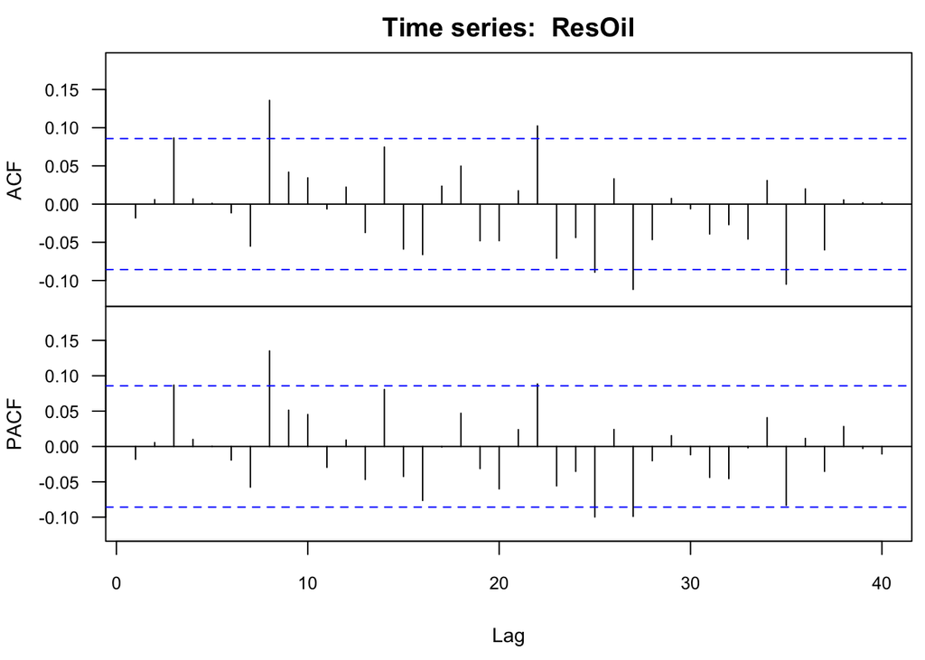

```
##       LAG         ACF1          PACF
##  [1,]   1 -0.018080995 -0.0180809946
##  [2,]   2  0.005879764  0.0055546576
##  [3,]   3  0.086546162  0.0867833650
##  [4,]   4  0.006777385  0.0099812647
##  [5,]   5  0.001092699  0.0002854634
##  [6,]   6 -0.011439596 -0.0191994585
##  [7,]   7 -0.055006498 -0.0575393113
##  [8,]   8  0.135755564  0.1351362760
##  [9,]   9  0.041865787  0.0513482077
## [10,]  10  0.034423461  0.0451948968
## [11,]  11 -0.006297216 -0.0294973887
## [12,]  12  0.022204374  0.0090662076
## [13,]  13 -0.037243228 -0.0467053757
## [14,]  14  0.074619955  0.0805743501
```

[output cut: 26 more lines]

```r
# Etude des résidus de la modélisation
ResOil <- auto.arima(r.oil, stationary=TRUE, seasonal=FALSE)$residuals
acf2y(ResOil)
```

```r
Box.test(ResOil)
```

```
##
##  Box-Pierce test
##
## data:  ResOil
## X-squared = 0.17785, df = 1, p-value = 0.6732
```

Conclusion : une modélisation des log-rendements avec un ARMA(1,1) nous rend des résidus qui passent le test de blancheur de Box-Pierce. La modélisation est donc raisonnable.

# Exercice 3 (algorithme Durbin-Levinson)

Voici une façon de coder l’algorithme.

```r
DLalgo <- function(x,p){
    ## on nomme la fonction d'autocovariance empirique
 gamma <- function(h){acf(x,h,plot=F,type="covariance")$acf[h+1]}

  ## initiatilisation
 k <- 1
 kappa = gamma(1)/gamma(0)
 sigma2 = gamma(0)*(1-kappa^2)
 phi <- 1:p ; phi[1] <- kappa

  ## algorithme
 while (k <= p){

   ### calcul annexe de la somme
   S = 0
   for (j in 1:k){ S <- S + phi[j] * gamma(k-j+1) }

   ### kappa
   kappa <- (gamma(k+1)-S)/sigma2

   ### phi
   for (j in 1:k){ phi[j] <- phi[j] - kappa * phi[k-j+1] }
   phi[k+1] <-kappa

   ### sigma2
   sigma2 <- sigma2 * (1-kappa^2)

   ### on incremente la boucle
  k <- k+1
 }
   ## resultats
   Result = list(phi,sigma2)
   return(Result)
 }
```

### Test

On retrouve les paramètres du modèle AR(2) de la Exercice 1, question 1 :

```r
DLalgo(AR2,1)
```

```
## [[1]]
## [1]  1.518004 -0.773296
##
## [[2]]
## [1] 0.8935402
```